# Module 10: State space models and multivariate time series

## Learning outcomes

- Learn the basics of parameter and state estimation for simple state space models
- Create and fit some basic multivariate time series models
- Understand the state of the art in time series models, including latent factor models and dynamic parameter models

Relevant JAGS file:

```
jags_statespace.R
jags_multivariate_AR.R
jags_multivariate_statespace.R
```

## Introduction to state space models

- State space models are a very general family of models that are used when we have a noisy time series of observations that are stochastically related to a hidden time series which is what we are really interested in
- For example they are used for palaeoclimate reconstruction when we observe pollen but are really interested in climate
- All state space models have two parts:
- The first part is called the *state equation* which links the observations to a latent *stochatic process*
- The second part of the model is called the *evoluation equation* which determines how the latent stochastic process changes over time

## A simple linear state space model

- We define \(y_t\) in the usual way, but write \(x_t\) for the hidden stochastic process
- For a simple linear state space model we have a *state equation* of:\[ y_t = \alpha_y + \beta_y x_t + \epsilon_t,\; \epsilon_t \sim N(0, \sigma_y^2)\]
- The *evolution equation* could be a random walk:\[ x_t = x_{t-1} + \gamma_t,\; \gamma_t \sim N(0, \sigma_x^2)\]
- The usual aim when fitting these models is to either estimate \(x_t\), or the parameters, or to predict future values of \(x_t\)
- This type of model is sometimes known as the *Kalman Filter*

## JAGS code for a linear state space model

```r
model_code = '
model
{
  # Likelihood
  for (t in 1:T) {
    y[t] ~ dnorm(alpha_y + beta_y * x[t], tau_y)
  }
  x[1] ~ dnorm(0, 0.01)
  for (t in 2:T) {
    x[t] ~ dnorm(x[t-1], tau_x)
  }

  # Priors
  tau_y <- 1/pow(sigma_y, 2)
  sigma_y ~ dunif(0, 100)
  tau_x <- 1/pow(sigma_x, 2)
  sigma_x ~ dunif(0, 100)
  }
'
```

## Priors for state space models

- You need to be very careful with state space models as it's very easy to create models which are ill-defined and crash
- For example, in the Kalman filter model before you can switch the sign of \(x_t\) and \(\beta_y\) and still end up with the same model
- It's advisable to either fix some of the parameters, or use extra data to calibrate the parameters of the state space model
- You can do better if you have multivariate observations or stricter requirements about the time series applied to \(x_t\)

## Example: palaeoclimate reconstruction

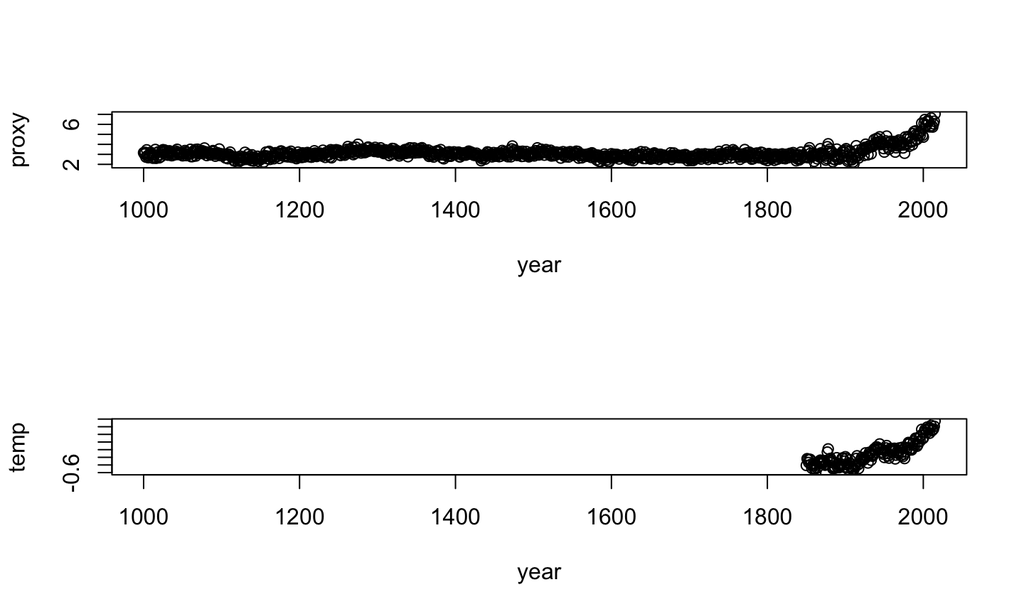

```r
palaeo = read.csv('https://raw.githubusercontent.com/andrewcparnell/tsme_course/master/data/palaeo.csv')
par(mfrow=c(2,1))
with(palaeo,plot(year, proxy))
with(palaeo,plot(year, temp)) # Only available for a subset
```

## Palaeoclimate reconstruction results

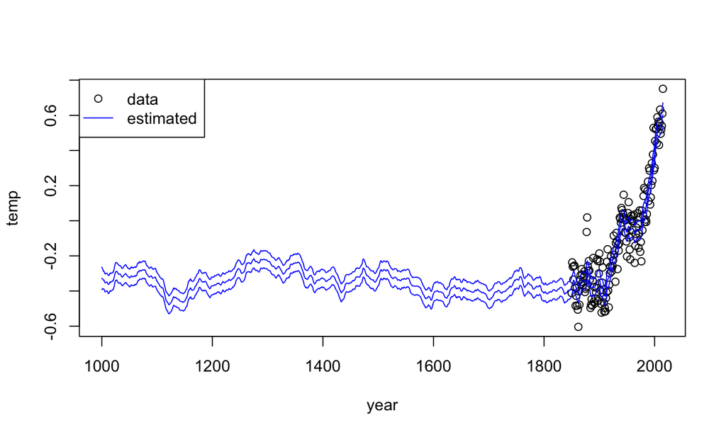

## Introduction to multivariate models

- Often we have multiple different observations at each time and we want to model them together
- For example, we might have multiple different climate variables observed, or multiple chemical signatures. If they are correlated then by fitting them separately we will lose precision
- If the observations are observed at different times for each time series we can use the NA trick, or create a latent state space model on which all measurements are regular

## The Vector AR model

- We can extend most of the models we have met to multivariate scenarios by applying the multivariate normal distribution instead of the univariate version
- Suppose now that \(y_t\) is a vector of length \(k\) containing all the observations at time \(t\)
- We can write:\[y_t = A + \Phi y_{t-1} + \epsilon_t,\; \epsilon_t \sim MVN(0, \Sigma)\]or equivalently\[y_t \sim MVN(A + \Phi y_{t-1}, \Sigma)\]
- where MVN is the multivariate normal distribution
- Here the parameter vector \(A\) controls the overall mean level for each of the \(k\) series, \(\Phi\) is a \(k \times k\) matrix which controls the influence on the current value of the previous time points of *both* series
- \(\Sigma\) here is a \(k \times k\) matrix that controls the variance of the process and the residual correlation between the two series (NB: this is different from the GP formulation we met yesterday)

## JAGS code for the VAR model

```r
model_code = '
model
{
  # Likelihood
  for (t in 2:T) {
    y[t, ] ~ dmnorm(mu[t, ], Sigma.Inv)
    mu[t, 1:k] <- A + Phi %*% y[t-1,]
  }
  Sigma.Inv ~ dwish(I, k+1)
  Sigma <- inverse(Sigma.Inv)

  # Priors
  for(i in 1:k) {
    A[i] ~ dnorm(0, 0.01)
    Phi[i,i] ~ dunif(-1, 1)
    for(j in (i+1):k) {
      Phi[i,j] ~ dunif(-1,1)
      Phi[j,i] ~ dunif(-1,1)
    }
  }
}
'
```

## Example: joint temperature/sea level models

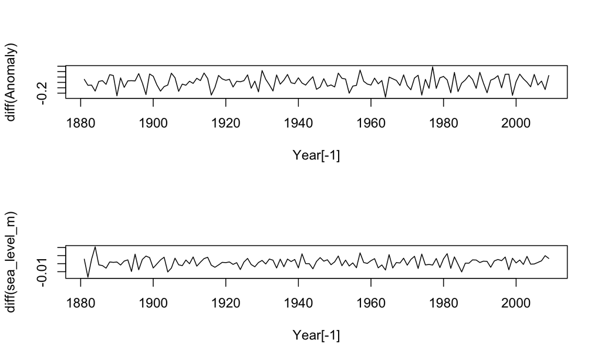

```r
par(mfrow=c(2,1))
with(bivariate_data, plot(Year[-1], diff(Anomaly), type='l'))
with(bivariate_data, plot(Year[-1], diff(sea_level_m), type='l'))
```

## VAR model results:

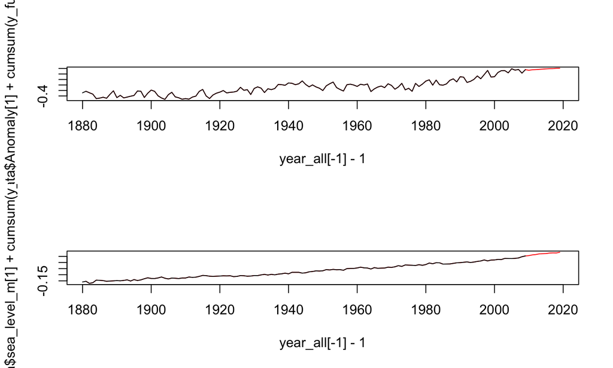

## Mixing up state space models, multivariate time series, Gaussian processes

- We can extend the simple state space model we met earlier to work for multivariate series
- We would have a state equation that relates our observations to a multivariate latent time series (possibly of a different dimension)
- We could change the time series model of the latent state to be an ARIMA model, an O-U process, a Gaussian process, or anything else you can think of!

## Dynamic linear models

- So far in all our models we have forced the time series parameters to be constant over time
- In a *Dynamic Linear Model* we have a state space model with :\[ y_t = F_t x_t + \epsilon_t,\; \epsilon_t \sim MVN(0, \Sigma_t)\]\[ x_t = G_t x_{t-1} + \gamma_t,\; \gamma_t \sim N(0, \Psi_t)\]
- The key difference here is that the transformation matrices \(F_t\) and \(G_t\) can change over time, as can the variance matrices \(\Sigma_t\) and \(\Psi_t\), possibly in an ARCH/GARCH type framework
- These are very hard models to fit in jags but simple versions can work

## Latent factor time series models

- If we have very many series, a common approach to reduce the dimension is to use Factor Analysis or Principal components
- In a latent factor model we write:\[y_t = B f_t + \epsilon_t\]where now \(B\) is a \(num series \times num factors\) factor loading matrix which transforms the high dimensional \(y_t\) into a lower dimensional \(f_t\).
- \(f_t\) can then be run using a set of univariate time series, e.g. random walks
- The \(B\) matrix is often hard to estimate and might require some tight priors

## Summary

- We have seen how to fit basic Bayesian state space models and observed some of their pitfalls
- We know how to create some simple multivariate time series models
- We have seen some of the more advanced ideas in time series models such as DLMs and dynamic factor models
- You are now an expert in Bayesian time series!